# Linear Regression

Dr Christopher Yau

16/10/2017

# Introduction

This practical will go through a series of exercises to familiarise yourselves with the basic functionality of the linear modelling capabilities of R. You will do the following things: - simulate your own linear model data sets - characterise the predictive accuracy of a linear model as a function of sample size - apply multiple regression and use simple approaches to determine variable importance - explore some real world data

Before you begin, make sure you have the `reshape2` and `ggplot2` packages. You can install these within Rstudio using the following commmands:

```r
install.packages("ggplot2")
install.packages("reshape2")
```

# Simulating data

You will simulate data to use for testing according to a linear model:
$$y_i = a x_i + b + \epsilon_i$$
where $(x_i,y_i)$ denotes the $i$-th measurement pair, $a$ is a regression coefficient (or slope) and $b$ is an intercept term. We will assume for now that the noise is normally distributed with zero mean and variance equal to $\sigma^2$, i.e. $\epsilon_i \sim N(0, \sigma^2)$.

First, define the values of the three model parameters $(a, b, \sigma^2)$:

```r
a = 2.5 # define slope term
b = -1 # define intercept term
sigma2 = 0.5 # define noise variance
```

Then we need to define some covariates ($x_i$), we will simulate 100 data points and generate these by randomly sampling from a Standard Normal distribution:

```r
n = 100 # number of data points to simulate
x = rnorm(n, mean=0, sd=1) # simulate the x's
```

Now we need to compute the measurements $y$ but we will also need to simulate the noise terms:

```r
e = rnorm(n, mean=0, sd=sqrt(sigma2)) # simulate noise terms (rnorm uses standard deviation not variance)
y = a*x + b + e # compute the y's
```

Now plot your simulated data. We will use ggplot so we first need to set up a data frame to hold our data:

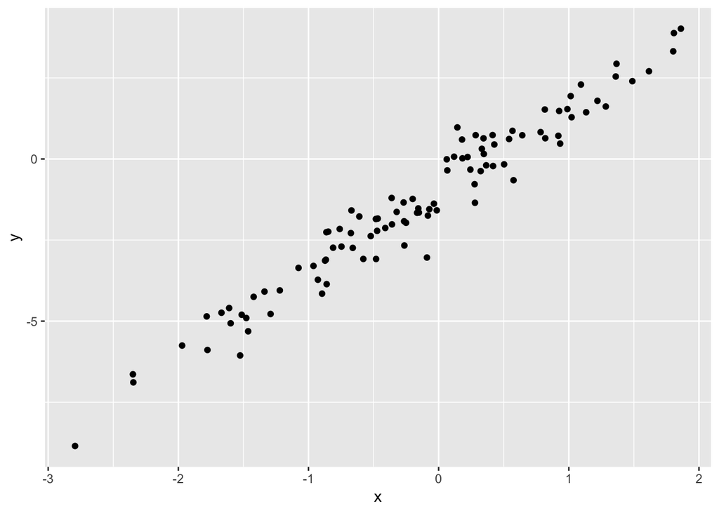

```r
library(ggplot2) # load ggplot library
xy_data = data.frame(x = x, y = y) # set up a data frame
ggplot(xy_data, aes(x=x, y=y)) + geom_point() # use ggplot to produce a scatter plot
```

We want to compare the data to the true linear relationship minus the noise. Lets set up a another vector to hold the true $(x, y)$ values:

```r
y_true = a*x + b # compute true y values
```

Now, overlay the true relationship on the scatter plot:

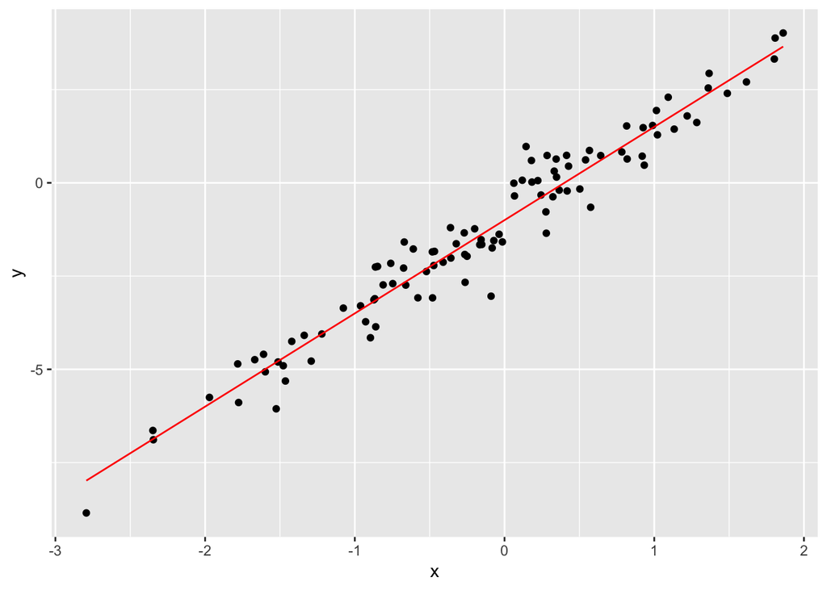

```r
xy_data$y_true = y_true # add to existing data frame
plt = ggplot(xy_data, aes(x=x, y=y)) + geom_point() # use ggplot to produce a scatter plot
plt = plt + geom_line(aes(x=x, y=y_true), colour="red") # plot the true relationship in red
print(plt) # use this to force Rstudio to display the plot (sometimes it will not do so automatically)
```

# Fitting linear models

Now, we will pretend that we did not simulate this data and use R’s `lm()` function to fit a linear model to this data by regressing $y$ on $x$:

```r
fit = lm(y ~ x, data = xy_data) # use the lm() function to fit a linear model
summary(fit) # display a text summary of the fit
```

```
##
## Call:
## lm(formula = y ~ x, data = xy_data)
##
## Residuals:
##      Min       1Q   Median       3Q      Max
## -1.83668 -0.37841  0.02813  0.36682  1.58727
##
## Coefficients:
##             Estimate Std. Error t value Pr(>|t|)
## (Intercept) -0.97607    0.05861  -16.65   <2e-16 ***
## x            2.51946    0.05826   43.24   <2e-16 ***
## ---
## Signif. codes:  0 '***' 0.001 '**' 0.01 '*' 0.05 '.' 0.1 ' ' 1
##
## Residual standard error: 0.5781 on 98 degrees of freedom
## Multiple R-squared:  0.9502, Adjusted R-squared:  0.9497
## F-statistic:  1870 on 1 and 98 DF,  p-value: < 2.2e-16
```

Now, extract the regression coefficients from the `fit` object and use it to generate a line of best fit:

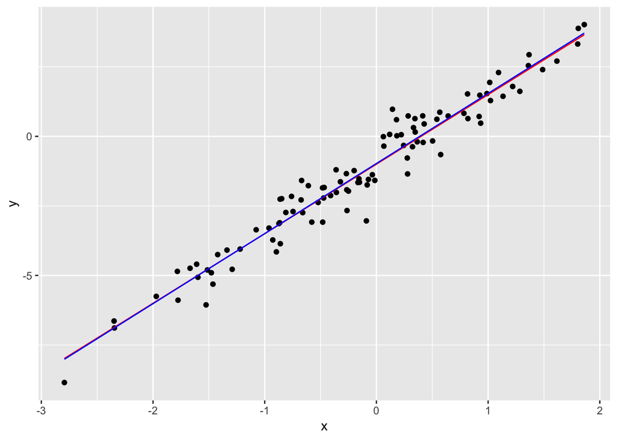

```r
b_hat = fit$coefficients[1] # extract the intercept term
a_hat = fit$coefficients[2] # extract the slope term
y_hat = b_hat + a_hat*x # generate the predicted values of y at the given values of x
xy_data$y_hat = y_hat # add to existing data frame
plt = ggplot(xy_data, aes(x=x, y=y)) + geom_point() # use ggplot to produce a scatter plot
plt = plt + geom_line(aes(x=x, y=y_true), colour="red") # plot the true relationship in red
plt = plt + geom_line(aes(x=x, y=y_hat), colour="blue") # plot the predicted relationship in blue
print(plt) # use this to force Rstudio to display the plot (sometimes it will not do so automatically)
```

The result shows a good correspondence between the fitted regression and the true relationship. Lets check by plotting the residuals (the difference between the data and the fitted values). This is done by accessing the `residuals` parameter of the `fit` object.

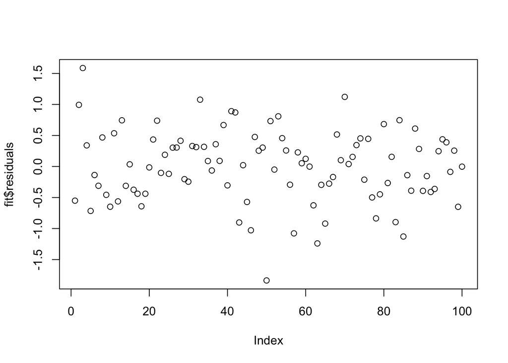

```r
plot(fit$residuals)
```

We can also histogram the residuals:

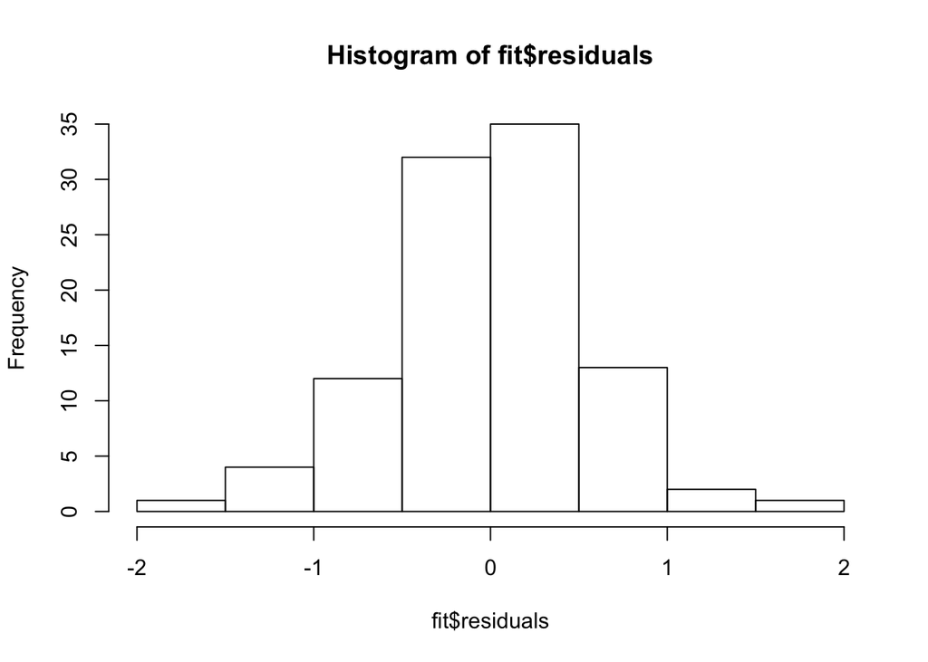

```r
hist(fit$residuals)
```

and compute the mean and variance of the residuals:

```r
print(mean(fit$residuals))
```

```
## [1] -1.965971e-17
```

```r
print(var(fit$residuals))
```

```
## [1] 0.3307937
```

We would expect the residuals to be centred on zero and have variance equal to the level used to generate the data. This is because if we substract off a (good) fit to the data then all that remains is the noise!

# Investigating sample size

Now lets investigate the quality of the predictions further by simulating more data sets and seeing how the sample size (number of data points) affects the quality of the fit.

Lets define some simulation parameters:

```r
n_simulations = 100 # number of simulations to do
sample_sizes = c( 10, 20, 30, 50, 100, 150, 200, 300, 500, 750, 1000 ) # range of sample sizes to try it
num_sample_sizes = length(sample_sizes)

# create a matrix to hold our results for each of the possible sample size and simulation number combinations
mse_matrix = matrix(0, nrow=n_simulations, ncol=num_sample_sizes)
rownames(mse_matrix) = c(1:n_simulations) # name the row names after the simulation number
colnames(mse_matrix) = sample_sizes # name the columns after the sample size
```

We will now do 100 simulations for a range of sample sizes and store the mean-squared prediction error in the matrix `mse_matrix`.

We will need a couple of nested `for` loops to run through the different simulations and sample size possibilities. The predicted values for $y$ are actually pre-computed and stored within the `lm()` output object:

```r
# for each sample size
for ( ni in 1:num_sample_sizes ) {
  n = sample_sizes[ni]

  # for each simulation
  for (it in 1:n_simulations) {

    x = rnorm(n, mean=0, sd=1) # generate x's
    e = rnorm(n, mean=0, sd=sqrt(sigma2)) # simulate noise
    y = a*x + b + e # compute the y's

    # set up a data frame and run lm()
    xy_data = data.frame(x=x, y=y)
    fit = lm(y ~ x, data = xy_data)

    # compute the mean squared error between the fit and the actual y's
    y_hat = fit$fitted.values
    mse_matrix[it, ni] = mean((y_hat-y)^2)

  }
}
```

Note in each iteration, we compute the predicted values `y_hat` based on the output of `lm()` and use this to compute the mean-squared error (mse) from the true value `y`.

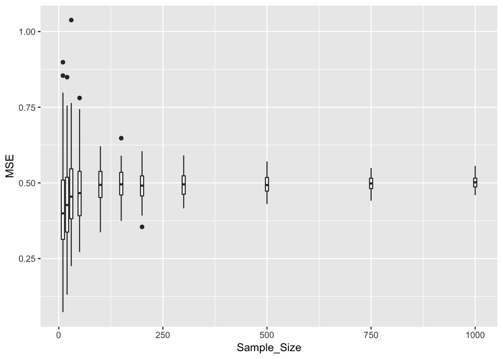

```r
library(reshape2)

mse_df = melt(mse_matrix) # convert the matrix into a data frame for ggplot
names(mse_df) = c("Simulation", "Sample_Size", "MSE") # rename the columns

# now use a boxplot to look at the relationship between mean-squared prediction error and sample size
mse_plt = ggplot(mse_df, aes(x=Sample_Size, y=MSE))
mse_plt = mse_plt + geom_boxplot( aes(group=Sample_Size) )
print(mse_plt)
```

Can you do something similar to work out the relationship between how accurate the regression coefficient estimates are as a function of sample size?

# Exercise

Fit a simple linear model to the two data sets supplied (`regression_1.Rdata` and `regression_2.Rdata`). In both files the $(x, y)$ data is saved in two vectors called `x` and `y`.

You can download the data files from Canvas and read them into R using the following code:

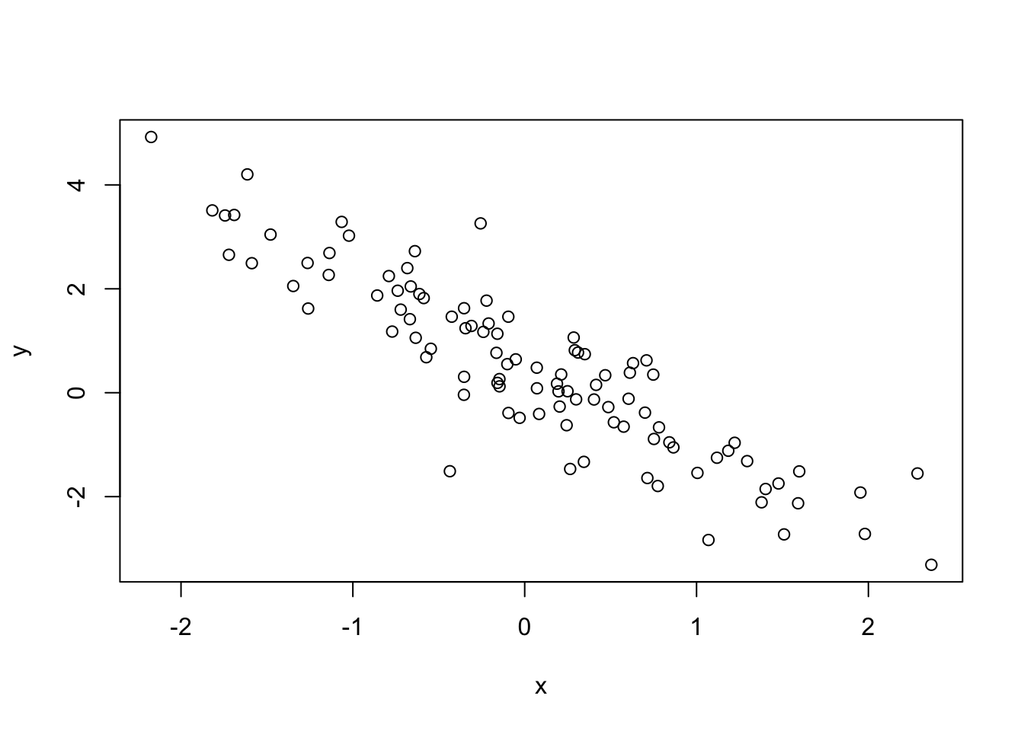

```r
load("regression_1.Rdata")
plot(x, y)
```

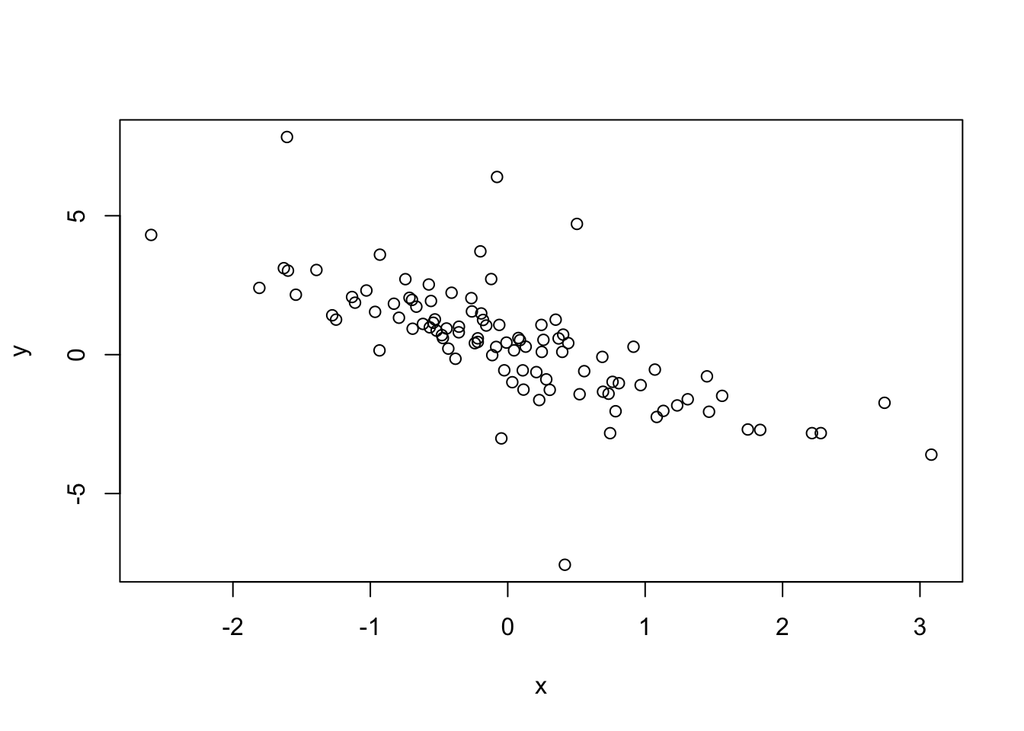

```r
load("regression_2.Rdata")
plot(x, y)
```

What do you notice is the difference between the two data sets when fitting the linear model?

# Multiple Regression

Now, lets try a multiple regression example of the form:
$$y_i = a + bx_i + cz_i + \epsilon_i$$
where $\epsilon \sim N(0, \sigma^2)$ and $y_i$ now depends on two covariates $x_i$ and $z_i$ and we now have 3 regression parameters $(a, b, c)$ and one noise variance to estimate $\sigma^2$.

We will use the data file `regression_3.Rdata` for this which contains the variables `x`, `y` and `z`:

```r
load("regression_3.Rdata")
dat = data.frame(x=x, y=y, z=z)
n = length(y)
```

Lets fit the regression model. We now need to regress $y$ on both $x$ and $z$ so we modify the `lm()` function call as follows:

```r
fit = lm(y~x+z, dat)
summary(fit)
```

```
##
## Call:
## lm(formula = y ~ x + z, data = dat)
##
## Residuals:
##     Min      1Q  Median      3Q     Max
## -1.7315 -0.5963  0.1658  0.4262  1.8615
##
## Coefficients:
##             Estimate Std. Error t value Pr(>|t|)
## (Intercept)  0.23050    0.07146   3.226  0.00171 **
## x           -0.46783    0.07008  -6.676 1.54e-09 ***
## z            0.78531    0.06848  11.468  < 2e-16 ***
## ---
## Signif. codes:  0 '***' 0.001 '**' 0.01 '*' 0.05 '.' 0.1 ' ' 1
##
## Residual standard error: 0.7071 on 97 degrees of freedom
## Multiple R-squared:  0.6722, Adjusted R-squared:  0.6655
## F-statistic: 99.46 on 2 and 97 DF,  p-value: < 2.2e-16
```

Check the output and use the steps before to assess the quality of the fit.

Now, lets fit the linear model manually using matrix-vector operations. From the lectures:
$$Y = X b + \epsilon$$
where $Y$ is a vector of $n \times 1$ measurements, $b$ is a vector of $p \times 1$ coefficients ($p=3$ in our case, 2 covariates + 1 intercept) and $X$ is an $n \times p$ design matrix.

First, lets create the *design matrix*, this is an $n \times 3$ matrix where each row contains $[1 x_i z_i]$:

```r
  X = matrix(0, nrow=n, ncol=3)
  X[, 1] = 1 # column of ones for the intercept term
  X[, 2] = x # column of covariate values for the x term
  X[, 3] = z # column of covariate values for the z term
```

Now, the least-squares estimate of the regression coefficients are given by the solution to the normal equations:
$$\hat{b} = (X^T X)^{-1} X^T y$$
where $^T$ denotes the *transpose* operation in `R` which is given by `t`. Hence,

```r
b_hat = solve(t(X)%*%X, t(X)%*%y)
print(b_hat)
```

```
##            [,1]
## [1,]  0.2305033
## [2,] -0.4678337
## [3,]  0.7853054
```

where `%*%` denotes *matrix multiplication*. You should obtain exactly the same estimates as `lm()`!

# Exercise

Now, let us consider another data set (`regression_4.Rdata`) where we will now fit three regression models. There are three variables in the data file called `x`, `y` and `z` respectively. In real world applications, we might want to do this to assess whether one or both variables are important in the regression model.

The three models are given by:
$$y_i = a + b x_i + \epsilon_i$$
$$y_i = a + b z_i + \epsilon_i$$
$$y_i = a + b x_i + c z_i + \epsilon_i$$
For each model compute the mean squared prediction error for the measurements $y$:

- Which model has the lowest mean squared error?
- Which covariate $x$ or $z$ is more important for prediction?

Rescale the values of both covariates to have mean 0 and variance 1 and re-fit the models. What do you notice change about the regression coefficients?

# Data Analysis

This is an exploratory exercise with real data and there is no given solution.

Fine particulate matter (PM2.5) are tiny particles in the air that reduce visibility and cause the air to appear hazy when levels are elevated. They are an air pollutant whose presence has a negative effect on human health.

You are provided with a data file `pmdata.csv` containing the following data:

- year: year of data in this row
- month: month of data in this row
- day: day of data in this row
- hour: hour of data in this row
- pm2.5: PM2.5 concentration (ug/m^3)
- DEWP: Dew Point
- TEMP: Temperature
- PRES: Pressure (hPa)
- Iws: Cumulated wind speed (m/s)

Construct a linear model to predict PM2.5 levels given the other parameters. Assess the model fit and determine which, if any, parameters are important for determining the pollution levels?